# Análise Ambiental

Fundamentos da Análise  
Ambiental Integrada

Luiz Diego Vidal Santos

## Visão Geral da Aula

### Tópicos

- 1 Elementos e fatores do meio físico
- 2 Meio biótico
- 3 Meio antrópico
- 4 Dados e indicadores do diagnóstico
- 5 Escala espacial e temporal
- 6 Sistemas ambientais
- 7 Dinâmica geoambiental
- 8 Planejamento e ordenamento territorial
- 9 Entrega do Estudo Orientado nº 4

**Objetivo da Aula**

Articular elementos físico-bióticos e antrópicos, dados primários e secundários e indicadores em diferentes escalas como base operacional da análise integrada, do diagnóstico ambiental e do ordenamento territorial.

# 1 - ELEMENTOS E FATORES AMBIENTAIS

## Componentes do sistema ambiental

### Meio físico

| Subsistema | Atributos centrais |
| --- | --- |
| Atmosfera | Clima, precipitação, temperatura, vento, erosividade |
| Litosfera | Geologia, geomorfologia, declividade, hipsometria |
| Pedosfera | Tipos de solo, profundidade, textura, fertilidade |
| Hidrosfera | Bacias, drenagem, hidrogeologia, qualidade |

### Meio biótico

- Cobertura vegetal e fitofisionomias
- Fauna terrestre e aquática
- Funcionalidade ecossistêmica (polinização, ciclagem, regulação)
- Espécies-bandeira, endêmicas e ameaçadas

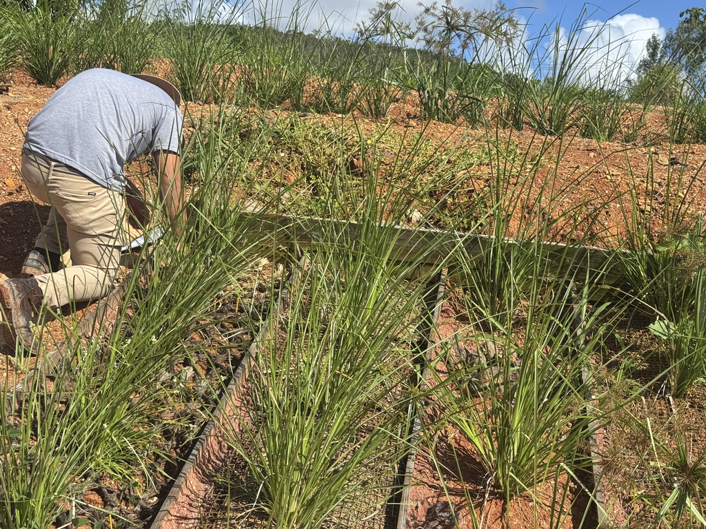

**Meio antrópico**

| Dimensão | Variáveis |
| --- | --- |
| Demográfica | População, densidade, dinâmica migratória |
| Econômica | Setores, renda, PIB, estrutura fundiária |
| Infraestrutural | Vias, saneamento, energia, comunicação |
| Cultural-simbólica | Patrimônio, identidades, tradições |
| Institucional | Governança, normas, conselhos, ZEE |

> Os três meios se articulam em **sistemas ambientais** com propriedades emergentes.

## Dados e indicadores do diagnóstico

### Dados primários e secundários

- **Secundários**: estações climáticas, IBGE, mapas, imagens orbitais; exigem escala e atualização compatíveis com a pergunta.
- **Primários**: coletas de campo (vegetação, fauna, qualidade da água, entrevistas).
- No meio biótico, o **esforço amostral** segue a curva do coletor (espécies acumuladas por dia de campo).

### Sensibilidade da área

- A significância do impacto depende da **vulnerabilidade natural** (declividade, nascentes, solos frágeis) e da qualidade ambiental prévia.

**Indicadores**

Cada impacto previsto exige indicadores específicos e mensuráveis (vazão, turbidez, riqueza de espécies, densidade demográfica), coletados com a mesma técnica e nos mesmos pontos ao longo do tempo, para permitir comparação multitemporal.

# 2 - ESCALA E SISTEMAS AMBIENTAIS

## Escala espacial e temporal

### Escala espacial

| Nível | Recorte típico | Aplicação |
| --- | --- | --- |
| Global | Bioma, continente | ODS, convenções |
| Regional | Bacia hidrográfica, estado | ZEE, Plano de Bacia |
| Local | Sub-bacia, município | Plano Diretor, Plano de Manejo |
| Sítio | Imóvel, talhão | CAR, PRAD, EIA |

### Princípios

- **Hierarquia**: cada nível impõe e é imposto por restrições dos níveis adjacentes.
- **Resolução**: cada questão exige escala compatível.
- **Não-transposição**: padrões de uma escala não se transferem mecanicamente a outra (falácia ecológica).

**Escala temporal**

| Tempo | Processo |
| --- | --- |
| Inst. - horas | Eventos extremos, precipitação, escoamento |
| Dias - meses | Sazonalidade, cultivos, fenologia |
| Anos - décadas | Mudanças no uso, sucessão, erosão |
| Séculos - milênios | Pedogênese, geomorfogênese |

A Análise Ambiental articula **processos de tempo curto** (dinâmica) e **estruturas de tempo longo** (herança geomorfopedológica).

## Dinâmica geoambiental e ordenamento

### Dinâmica geoambiental

Conjunto de **processos integrados** que reorganizam continuamente o sistema:

- Intemperismo e pedogênese
- Erosão, transporte e deposição
- Escoamento e infiltração
- Sucessão ecológica e ciclagem de nutrientes
- Mudanças de uso da terra

A leitura **dinâmica** é oposta à leitura **inventarial**: o ambiente é fluxo, não inventário.

**Ordenamento territorial**

Função do diagnóstico integrado para subsidiar:

- **ZEE** - Zoneamento Ecológico-Econômico
- **ZEEC** - Zoneamento Costeiro
- **Planos de Bacia** - outorga, enquadramento, cobrança
- **Planos Diretores Municipais** - macrozoneamento, perimetro urbano
- **Plano de Manejo de UCs** - zona de proteção integral, uso, amortecimento

A Análise Ambiental fornece a **base territorial** para todos esses instrumentos.

# Referências

## Bibliografia da aula

- CASTRO, C. M.; LEMOS, C. C. **Planejamento ambiental**. Rio de Janeiro: Fundação Cecierj, 2016.
- ARRUDA, A. G. F. “Planejamento territorial” e “ordenamento territorial”: uma busca da compreensão usual e epistemológica na gestão do território. **Akrópolis**, Umuarama, v. 21, n. 2, p. 125-132, jul./dez. 2013.
- CHRISTOFOLETTI, A. **Modelagem de sistemas ambientais**. São Paulo: Edgard Blücher, 1999.
- DREW, D. **Processos interativos homem-meio ambiente**. Rio de Janeiro: Bertrand Brasil, 1989.
- TAUK-TORNISIELO, S. M. (org.). **Análise ambiental**: uma visão multidisciplinar. 2. ed. São Paulo: Editora UNESP, 1996.
- CASTRO, I. E. de. O problema da escala. In: CASTRO, I. E. de; GOMES, P. C. da C.; CORRÊA, R. L. (org.). **Geografia: conceitos e temas**. Rio de Janeiro: Bertrand Brasil, 1995.
- SÁNCHEZ, L. E. **Avaliação de impacto ambiental**: conceitos e métodos. 2. ed. São Paulo: Oficina de Textos, 2013.